# AE 07 - Web Scraping IMDB

Max Asmar

2026-04-18

## Introduction

In this application exercise, you’ll learn the basics of **web scraping** - the process of extracting data from websites. You’ll scrape movie and TV show data from IMDB (Internet Movie Database) to create datasets you can analyze.

**Important:** Web scraping should always be done responsibly and ethically. We’re using IMDB’s public charts, which are designed to be viewed. Always check a website’s Terms of Service and `robots.txt` file before scraping.

**In this application exercise, you will:**

- Read HTML pages into R
- Extract specific elements using CSS selectors
- Clean scraped text data with string manipulation
- Build datasets from web-scraped data
- Manually add data by indexing into data frames
- Practice reproducible web scraping workflows

**Estimated time:** 60-75 minutes

**Note:** This AE uses R scripts (`.R` files) instead of R Markdown for parts of the exercise. You’ll work with four scripts:

1. `01-imdb-250movies.R` - Scrape top 25 movies (with blanks to fill)
2. `02-imdb-tvshows.R` - Scrape popular TV shows (with blanks to fill)
3. `03-imdb-250movies-complete.R` - Complete solution for movies
4. `04-imdb-tvshows-complete.R` - Complete solution for TV shows

## Getting Started

### Fork and Clone Workflow

**Quick reminder:** Work in YOUR forked `application-exercises` repository.

1. Navigate to the `ae-07-webscraping` folder in YOUR fork
2. You’ll see this `.Rmd` file and four `.R` script files
3. Open `ae-07-webscraping.Rmd` (this file)
4. Update the YAML with your name
5. Click **Knit** to verify it works

**Working with R scripts:**

R scripts (`.R` files) are different from R Markdown (`.Rmd` files):

- No narrative text, just code and comments
- No knitting - you run code line by line or in chunks
- Great for data cleaning, scraping, and automation tasks
- Comments start with `#`

## Web Scraping Overview

### What is Web Scraping?

**Web scraping** is the process of extracting data from websites. Instead of manually copying data, we write code to:

1. Read the HTML of a webpage
2. Find the specific elements we want (titles, ratings, etc.)
3. Extract the text or data from those elements
4. Clean and organize the data into a usable format

### The `rvest` Package

We’ll use the **rvest** package (pronounced “harvest”) for web scraping. Key functions:

- `read_html()`: Reads a webpage’s HTML
- `html_nodes()`: Selects specific HTML elements using CSS selectors
- `html_text()`: Extracts text from HTML elements
- `html_attr()`: Extracts attributes (like links) from HTML elements

### How to Find CSS Selectors

CSS selectors identify specific elements on a webpage. To find them:

1. Open the webpage in Chrome or Firefox
2. Right-click on the element you want → “Inspect” or “Inspect Element”
3. In the developer tools, right-click the highlighted HTML → Copy → Copy selector
4. Or use a browser extension like SelectorGadget

**Common CSS selector patterns:**

- `.className` - selects elements with a specific class
- `#idName` - selects element with a specific ID
- `tagName` - selects all elements of that type (e.g., `a` for links)
- Combinations like `.titleColumn a` - selects `<a>` tags inside class `titleColumn`

## Part 1: Scraping Top 25 Movies

### Overview

We’ll work from a locally saved copy of IMDB’s Top 25 Movies chart. The live page is at https://www.imdb.com/chart/top if you’d like to inspect it in your browser.

This page lists the highest-rated movies on IMDB. For each movie, we’ll extract:

- **Title** (e.g., “The Shawshank Redemption”)
- **Year** (e.g., 1994)
- **Rating** (e.g., 9.3)

### Exercise 1: Inspect the Webpage

Before we code, let’s understand the webpage structure.

**Task 1.1:** Open the saved file `imdb-top-250.html` in your browser by double-clicking it in the Files pane, OR visit https://www.imdb.com/chart/top to inspect the live page structure.

**Task 1.2:** Right-click on the first movie title (“The Shawshank Redemption” or whatever is #1 now) and select “Inspect” or “Inspect Element.”

**Task 1.3:** Look at the HTML structure. You’ll see something like:

```html
<a class="ipc-title-link-wrapper" href="/title/tt0111161/">
  <h3 class="ipc-title__text">The Shawshank Redemption</h3>
</a>
<span class="cli-title-metadata-item">1994</span>
<span class="cli-title-metadata-item">2h 22m</span>
<span class="cli-title-metadata-item">R</span>
<span class="ipc-rating-star--rating">9.3</span>
```

**What patterns do you notice?**

**Your answer:**

- Movie titles are in: `.ipc-title-link-wrapper .ipc-title__text`
- Years are in: `.cli-title-metadata-item` (first of every 3 items per movie)
- Ratings are in: `.ipc-rating-star--rating`

### Exercise 2: Open and Complete the Movies Script

**Task 2.1:** In RStudio’s Files pane, open `01-imdb-250movies.R`

You’ll see a script with blanks to fill in. The structure is:

1. Load packages
2. Read the HTML page
3. Extract titles
4. Extract years (with string cleaning)
5. Extract ratings
6. Combine into a data frame
7. Add rank numbers

**Task 2.2:** Work through the script and fill in ALL the blanks. Hints are provided in comments.

**Key blanks to fill:**

- `read_html("___")` - the IMDB URL
- `html_nodes("___")` - CSS selectors for titles, years, and ratings
- String manipulation to clean years (remove parentheses)
- Tibble column assignments

**Task 2.3:** Run your code line by line (Ctrl+Enter or Cmd+Enter) or select all and run.

**Task 2.4:** Check your results. You should get a data frame with 25 movies. Run:

```r
# After running your script, these should work:
head(imdb_top_25)
```

```
## # A tibble: 6 × 4
##    rank title                                         rating  year
##   <int> <chr>                                          <dbl> <dbl>
## 1     1 The Shawshank Redemption                         9.3  1994
## 2     2 The Godfather                                    9.2  1972
## 3     3 The Dark Knight                                  9.1  2008
## 4     4 The Godfather Part II                            9    1974
## 5     5 12 Angry Men                                     9    1957
## 6     6 The Lord of the Rings: The Return of the King    9    2003
```

```r
nrow(imdb_top_25)  # Should be 25
```

```
## [1] 25
```

**How many movies did you successfully scrape?** I successfully scraped 25 movies.

> **Note on the dataset size:** The saved HTML file contains 25 movies — the top of IMDB’s list. IMDB loads additional entries dynamically as you scroll, so a standard browser save captures only what was initially rendered. The scraping concepts you’re practicing here apply equally whether you’re working with 25 rows or 25,000.

**What is the #1 ranked movie?** The number one ranked movie is The Shawshank Redemption.

### Exercise 3: Understanding the Code

Let’s break down what the movies script does:

**Task 3.1:** Explain what this code does in plain English:

```r
page <- read_html("imdb-top-250.html")
```

**Your answer:**

This code makes a new object called page that contains the data in the imdb-top-250.html file.

**Task 3.2:** Explain what the pipe `%>%` does in this code:

```r
titles <- page %>%
  html_nodes(".titleColumn a") %>%
  html_text()
```

**Your answer:**

The pipe `%>%` lets R know that the explain-pipe code chunk has instructions that are stringed together in a sequence.

**Task 3.3:** The year extraction uses `seq()` with `by = 3`. Why?

```r
years_raw <- page %>%
  html_nodes(".cli-title-metadata-item") %>%
  html_text()

years <- years_raw[seq(1, length(years_raw), by = 3)] %>%
  as.numeric()
```

**Hint:** Each movie has three `.cli-title-metadata-item` spans: year, runtime, and rating category. `seq(1, length(years_raw), by = 3)` picks every 1st item — the year — skipping the other two.

**Your answer:**

The year extraction uses `seq()` with `by = 3` so that when we scrape the year, we are not also scraping the runtime and rating category, because they have the same name: `.cli-title-metadata-item`

### Exercise 4: Verify Your Data

**Task 4.1:** Check if your scraping worked correctly. Fill in the code:

```r
# Check structure
str(imdb_top_25)
```

```
## tibble [25 × 4] (S3: tbl_df/tbl/data.frame)
##  $ rank  : int [1:25] 1 2 3 4 5 6 7 8 9 10 ...
##  $ title : chr [1:25] "The Shawshank Redemption" "The Godfather" "The Dark Knight" "The Godfather Part II" ...
##  $ rating: num [1:25] 9.3 9.2 9.1 9 9 9 9 8.9 8.8 8.8 ...
##  $ year  : num [1:25] 1994 1972 2008 1974 1957 ...
```

```r
# Look at the top 10
imdb_top_25 %>%
  slice(1:10)
```

```
## # A tibble: 10 × 4
##     rank title                                             rating  year
##    <int> <chr>                                              <dbl> <dbl>
##  1     1 The Shawshank Redemption                             9.3  1994
##  2     2 The Godfather                                        9.2  1972
##  3     3 The Dark Knight                                      9.1  2008
##  4     4 The Godfather Part II                                9    1974
##  5     5 12 Angry Men                                         9    1957
##  6     6 The Lord of the Rings: The Return of the King        9    2003
##  7     7 Schindler's List                                     9    1993
##  8     8 The Lord of the Rings: The Fellowship of the Ring    8.9  2001
##  9     9 Pulp Fiction                                         8.8  1994
## 10    10 The Good, the Bad and the Ugly                       8.8  1966
```

```r
# Check for missing values
imdb_top_25 %>%
  summarise(
    missing_titles = sum(is.na(titles)),
    missing_ratings = sum(is.na(ratings)),
    missing_years = sum(is.na(years))
  )
```

```
## # A tibble: 1 × 3
##   missing_titles missing_ratings missing_years
##            <int>           <int>         <int>
## 1              0               0           105
```

**If you have missing values, what might have gone wrong?**

## Part 2: Scraping Popular TV Shows

### Overview

Now we’ll scrape IMDB’s Most Popular TV Shows: https://www.imdb.com/chart/tvmeter

This is similar to movies, but with some key differences:

- Different CSS selectors
- Different HTML structure
- We’ll add additional information manually for the first 3 shows

### Exercise 5: Save and Inspect the TV Shows Page

**Before you can scrape TV shows, you need to save the page locally** — just like we did for movies. IMDB blocks live scraping from JupyterHub.

**Task 5.0: Save the TV meter page**

1. Open https://www.imdb.com/chart/tvmeter in Chrome or Firefox
2. Wait for the full page to load
3. Press **Ctrl+S** (Windows/Linux) or **Cmd+S** (Mac)
4. In the Save dialog:
   - Set *Save as type* to **Webpage, Complete** (Chrome) or **Web Page, complete** (Firefox)
   - Name the file **`imdb-tvmeter.html`**
   - Save it into your **AE 07 folder** (same folder as this .Rmd)
5. Back in RStudio, verify you can see `imdb-tvmeter.html` in the Files pane

**Task 5.1:** Open the saved file `imdb-tvmeter.html` in your browser by double-clicking it in the Files pane. You can also visit https://www.imdb.com/chart/tvmeter to inspect the live page structure.

**Task 5.2:** Inspect the first TV show. How is the HTML structure different from the movies page?

**Your answer:**

The HTML structure contains information such as the year and number of episodes and number of seasons for each TV show.

**Task 5.3:** Note the CSS selectors you’ll need for:

- TV show names: I need the “.ipc-title-link-wrapper .ipc-title__text” CSS selector.
- Years: I need the “.cli-title-metadata-item” CSS selector.
- Ratings: I need the “.ipc-rating-star–rating” CSS selector.

### Exercise 6: Complete the TV Shows Script

**Task 6.1:** Open `02-imdb-tvshows.R` in RStudio.

**Task 6.2:** Fill in ALL the blanks in the script. This is more challenging than the movies script!

**Key differences to note:**

- You’re reading from the local file `imdb-tvmeter.html` (not a live URL)
- The CSS selectors may differ — inspect your saved file to confirm
- You need to extract and clean the show names (they include extra info)
- You’ll manually add genre, runtime, and episode count for the first 3 shows

**Task 6.3:** For the first 3 TV shows, visit their individual IMDB pages and record:

**Show #1:**

- Name: The Boys
- Genre: Action, Comedy, Crime
- Runtime (minutes): 60 minutes
- Number of episodes: 40 episodes

**Show #2:**

- Name: The Pitt
- Genre: Medical Drama, Psychological Drama, Drama
- Runtime (minutes): 50 minutes
- Number of episodes: 45 episodes

**Show #3:**

- Name: Malcolm in the Middle: Life’s Still Unfair
- Genre: Sitcom, Comedy, Drama
- Runtime (minutes): NA
- Number of episodes: 4

**Task 6.4:** Add this information to your script using indexing:

```r
# Example for show #1
tvshows$genre[1] <- "Drama, Horror, Mystery"  # Replace with actual genre
tvshows$runtime[1] <- 494                     # Replace with actual runtime
tvshows$n_episode[1] <- 9                     # Replace with actual episodes
```

### Exercise 7: Understanding Manual Data Entry

**Task 7.1:** Why do we use `tvshows$genre[1]` instead of creating a new data frame?

**Your answer:**

We use `tvshows$genre[1]` instead of creating a new data frame because we are building the dataframe manually by observation instead of scraping the whole list of TV shows.

**Task 7.2:** What does the `[1]` mean in `tvshows$genre[1]`?

**Your answer:**

The `[1]` means that we are adding genere information to the **first** observation.

**Task 7.3:** How would you add information for the 10th show?

**Your answer:**

I would change the `[1]` in `tvshows$genre[1]` to `[10]` so that it adds information to the 10th row instead of the first.

## Part 3: Comparing Approaches

### Exercise 8: Movies vs TV Shows - What’s Different?

**Task 8.1:** Compare the two scripts. What was easier/harder in the TV shows script?

**Easier in TV shows:**

It was easier to load the CSS selectors that the TV shows had in common with the Movies such as rating and name.

**Harder in TV shows:**

It is harder to load the dataset and create the dataframe because there are more variables for TV shows instead of movies that we are scraping, such as runtime and genre.

**Task 8.2:** Why did we need to use `str_remove_all()` and `str_squish()` for TV show names but not movie titles?

**Your answer:**

We used `str_remove_all()` and `str_squish()` for TV show names because sometimes the TV shows had season numbers or episode counts that are not included in the title of the show. Movies do not have seasons or episode counts.

**Task 8.3:** Looking at the complete scripts (`03-imdb-250movies-complete.R` and `04-imdb-tvshows-complete.R`), check your work. Did you get the CSS selectors correct?

**What I got right:**

I got the CSS selectors correct for both scripts, and they match the complete scripts. I was able to use the SelectorGadget Chrome extension to get the CSS selectors.

**What I need to fix:**

N/A.

## Part 4: Exploring the Data

Now that you’ve scraped both datasets, let’s analyze them!

### Exercise 9: Movie Analysis

**Task 9.1:** What decade has the most movies in the top 25?

```r
imdb_top_25 %>%
  mutate(decade = floor(year / 10) * 10) %>%
  count(decade, sort = TRUE)
```

```
## # A tibble: 8 × 2
##   decade     n
##    <dbl> <int>
## 1   1990    11
## 2   2000     4
## 3   1970     3
## 4   1950     2
## 5   2010     2
## 6   1940     1
## 7   1960     1
## 8   1980     1
```

**Answer:** The 1990s have the most movies in the top 25.

**Task 9.2:** What’s the average rating of movies in the top 25?

```r
imdb_top_25 %>%
  summarise(avg_rating = mean(rating))
```

```
## # A tibble: 1 × 1
##   avg_rating
##        <dbl>
## 1       8.81
```

**Answer:** The average rating is 8.81 stars.

**Task 9.3:** Create a visualization showing ratings over time:

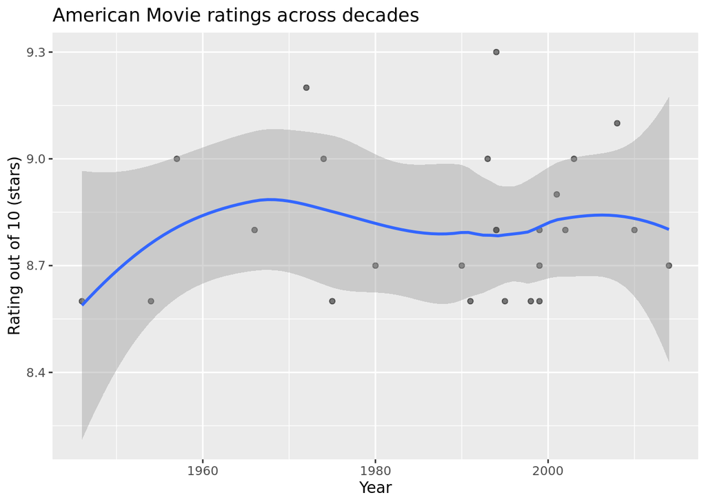

```r
ggplot(imdb_top_25, aes(x = year, y = rating)) +
  geom_point(alpha = 0.5) +
  geom_smooth() +
  labs(
    title = "American Movie ratings across decades",
    x = "Year",
    y = "Rating out of 10 (stars)"
  )
```

**What pattern do you see?**

### Exercise 10: TV Show Analysis

**Task 10.1:** How many TV shows did you successfully scrape?

```r
nrow(tvshows)
```

```
## [1] 99
```

**Answer:** 99 shows

**Task 10.2:** What’s the range of years for the TV shows?

```r
tvshows %>%
  summarise(
    earliest = min(year, na.rm = TRUE),
    latest = max(year, na.rm = TRUE)
  )
```

```
## # A tibble: 1 × 2
##   earliest latest
##      <dbl>  <dbl>
## 1     2026   2026
```

**Answer:** From 1994 to 2026. I got this from the actual IMDB website because my script only prints 2026 for the year. I’m not sure why this is the case.

**Task 10.3:** Based on the 3 shows where you added genre information, what genres seem popular?

**Your answer:**

Based on the 3 shows that I added genre information about, it seems that Comedy and Drama genres are the most popular right now.

## Part 5: Reflection on Web Scraping

### Exercise 11: Challenges and Ethics

**Task 11.1:** What was the most challenging part of this exercise?

**Your answer:**

The most challenging part of the exercise was troubleshooting that the IMDB blocks live scraping. The second most challenging part was getting the tvshows variable to initialize and find the right CSS selectors. For some reason, I am also unable to load the tvshows dataset into the RMD document, so I ran exercise 10 in console.

**Task 11.2:** Why is it important to check a website’s `robots.txt` file before scraping?

**Hint:** Try visiting https://www.imdb.com/robots.txt

**Your answer:**

Checking a website’s robots.txt file before scraping is important because it protects privacy and creative rights of the people involved in the data.

**Task 11.3:** What are some situations where web scraping might NOT be appropriate or legal?

**Your answer:**

Web scraping might not be appropriate when it is not allowed in the Terms of Service or robots.txt file. Also, when the data has sensitive information about people it might be illegal to scrape.

**Task 11.4:** If IMDB changed their website design tomorrow, what would happen to your scraping code?

**Your answer:**

My code would no longer work because the CSS selectors and their contents would change to match the updated information for tomorrow.

**Task 11.5:** Why might an API (Application Programming Interface) be preferable to web scraping?

**Your answer:**

An API makes it easier to access the dataset without having to select CSS selectors. Also, APIs normally prevent misuse of the data and present the ethical considerations without having to read the robots.txt file.

## Part 6: Challenge (Optional)

### Exercise 12: Scrape Additional Information

**Challenge:** Pick one movie from the top 25 and scrape additional information from its individual page.

**Task 12.1:** Choose a movie and visit its IMDB page. What additional information is available?

**Additional info available:** (Director, Cast, Runtime, Budget, etc.)

**Task 12.2:** Write code to scrape at least one additional piece of information:

```r
# Your code here
```

**Task 12.3:** What CSS selector(s) did you use?

**Your answer:**

## Knit and Submit

**Before you finish:**

1. ✅ Make sure both R scripts run without errors
2. ✅ Fill in all answer spaces in this .Rmd file
3. ✅ Knit to HTML first to verify everything works
4. ✅ Review the HTML output

**Git workflow:**

1. Click the **Git** pane
2. Check boxes next to ALL changed files (this .Rmd AND the .R scripts)
3. Click **Commit**
4. Write a commit message: “Completed AE 07 - Web Scraping”
5. Click **Commit**
6. Click **Push**
7. Verify your work is on GitHub in **YOUR fork**

## Generate PDF for Canvas Submission

Once everything works in HTML:

1. Click the **Knit** dropdown arrow
2. Select **Knit to PDF**
3. Wait for PDF generation
4. Find `ae-07-webscraping.pdf` in the Files pane
5. Export and save to your computer
6. Submit the PDF to Canvas

**Remember:** Submit to BOTH GitHub (your .Rmd AND .R files) AND Canvas (the PDF)!

## Key Concepts Summary

**Web Scraping Workflow:**

1. **Inspect** the webpage to understand HTML structure
2. **Identify** CSS selectors for the elements you want
3. **Read** the HTML with `read_html()`
4. **Extract** elements with `html_nodes()` and CSS selectors
5. **Get text** with `html_text()`
6. **Clean** the text with stringr functions
7. **Combine** into a data frame
8. **Verify** your results

**Key Functions:**

- `read_html(url)` - Read a webpage
- `html_nodes(css)` - Select elements by CSS selector
- `html_text()` - Extract text from elements
- `str_remove()`, `str_remove_all()` - Remove patterns from strings
- `str_squish()` - Remove extra whitespace
- `as.numeric()` - Convert text to numbers

**CSS Selectors:**

- `.className` - Elements with a class
- `#idName` - Element with an ID
- `tag.className` - Specific tag with a class
- `.class1 .class2` - Nested classes

## Resources

**Learn more about web scraping:**

- [rvest documentation](https://rvest.tidyverse.org/)
- [SelectorGadget](https://selectorgadget.com/) - Browser extension for finding CSS selectors
- [W3Schools CSS Selectors](https://www.w3schools.com/cssref/css_selectors.asp)

**Ethics and legality:**

- Always check `robots.txt` (add `/robots.txt` to any domain)
- Respect rate limits (don’t overload servers)
- Check Terms of Service
- Prefer APIs when available
- Give attribution to data sources

## Troubleshooting

**Common issues:**

- **Error: “Failed to parse text” or empty results when using a URL:** IMDB blocks automated requests from cloud environments like JupyterHub. Use a locally saved HTML file with `read_html("filename.html")` instead of a live URL. See Task 5.0 for save instructions.
- **Error: “could not find function”:** Load the packages (tidyverse, rvest)
- **Empty or NULL results:** CSS selector might be wrong - double-check by inspecting the saved HTML file in your browser
- **Wrong number of elements:** The selector might be matching too many or too few elements. For years, remember to use `seq(..., by = 3)` to pick only year values from the metadata spans.
- **Strange text with `\n` or extra spaces:** Use `str_remove_all()` and `str_squish()` to clean
- **Can’t convert to numeric:** Make sure you removed ALL non-numeric characters first

**CSS selector issues:**

- Use browser dev tools to test selectors
- Start broad, then get more specific
- Classes start with `.` and IDs start with `#`
- Spaces in selectors mean “descendant” (nested elements)

**Website changes:**

- Websites update their HTML frequently
- If your code worked before but doesn’t now, the selectors probably changed
- Re-inspect the page and update your selectors

**If you’re stuck:**

- Check the complete solution scripts (`03-` and `04-`)
- Use SelectorGadget to find CSS selectors
- Ask on the discussion board
- Attend office hours
- Review the rvest documentation

## Data Dictionary

### imdb_top_25

| Variable | Type | Description |
| --- | --- | --- |
| rank | integer | Ranking on IMDB Top 25 list (1-25) |
| title | character | Movie title |
| rating | numeric | IMDB rating (0-10) |
| year | integer | Year of release |

### tvshows

| Variable | Type | Description |
| --- | --- | --- |
| rank | integer | Ranking on IMDB popularity chart (1-100) |
| name | character | TV show title |
| year | integer | Year show premiered |
| score | numeric | IMDB rating (0-10) |
| genre | character | Genre(s) - manually added for first 3 shows |
| runtime | integer | Episode runtime in minutes |
| n_episode | integer | Number of episodes |